# Functions in R

### 6.1 What are Functions ?

A function is a set of statements organized together to perform a specific task. A programmer builds a function to avoid repeating the same task, or reduce complexity. R has a large number of in-built functions and the user can create their own functions.

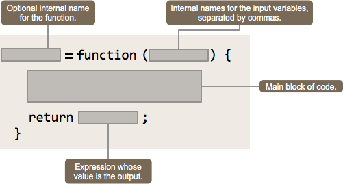

#### 6.1.1 Syntax for writing Functions in R

An R function is created by using the keyword “function”. The basic syntax of a function definition is as follows:

```r
function_name = function (argument) {
statement
}
```

Lets look at an example of simple function in R

```r
myfunc = function(x){
  range = max(x) - min(x)
  return(range)
}
myfunc(1:10)
```

```
[1] 9
```

#### 6.1.2 Components of a function

The first component of the function code is the name of the function. Make sure that it is not same as existing R functions. You can quickly check for that by looking up documentation for that function. If function with the same name exist, documentation will show up.

Next component is arguments which the function takes, they are listed in brackets beside the keyword ‘function’. An argument is a placeholder. When a function is invoked, you pass a value to the argument. Arguments are optional; that is, a function may contain no arguments and can take multiple arguments as well. Also arguments can have default values.

The function body contains a collection of statements that defines what the function does. Inside the curly braces whatever processing you want to do is contained.

In the end line there you return the result of your computation by using function return. The return value of a function is the last expression in the function body to be evaluated. Returning a result is not necessary.

#### 6.1.3 To call a function

Arguments used in the function declaration are used while calling the function. Lets see an example here:

```r
# function to print a raised to the power b
power = function(a,b) {
outcome = a**b
print(paste(a,"raised to the power", b, "is", outcome))
}
```

```r
power(2,3)
```

```
[1] "2 raised to the power 3 is 8"
```

**Exercise**: Let’s define a function that converts temperatures from Fahrenheit to Kelvin

```r
fahrenheit_to_kelvin = function(temp) {
  kelvin = ((temp - 32) * (5 / 9)) + 273.15
  return(kelvin)
}
```

```r
# freezing point of water
fahrenheit_to_kelvin(32)
```

```
[1] 273.15
```

```r
# boiling point of water
fahrenheit_to_kelvin(212)
```

```
[1] 373.15
```

### 6.2 Types of Functions

R has many in-built functions which can be directly called in the program without defining them first. We can also create and use our own functions referred as user defined functions.

#### 6.2.1 Built-in Function

Built-in functions are those functions whose meaning and working is already defined within the function’s body and they are kept somewhere within the packages or libraries of R language. These pre-defined functions make programmers task easier.

Simple examples of built-in functions are seq(), mean(), max(), sum(x), and paste() etc.

```r
# Create a sequence of numbers from 32 to 44.
print(seq(22,44))
```

```
 [1] 22 23 24 25 26 27 28 29 30 31 32 33 34 35 36 37 38 39 40 41 42 43 44
```

```r
# Find mean of numbers from 25 to 82.
print(mean(45:85))
```

```
[1] 65
```

```r
# Find sum of numbers frm 41 to 68.
print(sum(51:80))
```

```
[1] 1965
```

#### 6.2.2 User-defined Function

We can create user-defined functions in R. They are specific to what a user wants and once created they can be used like the built-in functions.

```r
mysummary = function(x){
  s1 = min(x)
  s2 = max(x)
  s3 = mean(x)
  s4 = sd(x)
  s5 = median(x)
  summary = list(min=s1,max=s2,mean=s3,sd=s4,median=s5)
return(summary)
}
mysummary(2:90)
```

```
$min
[1] 2

$max
[1] 90

$mean
[1] 46

$sd
[1] 25.83602

$median
[1] 46
```

### 6.3 Arguments in a Function

Next we’ll learn about how to give default arguments to your function. While declaring your arguments , you can pass default values. Modifying the function that we wrote above, we’ll now write a function, which takes input a vector x and a value y. Function first multiplies the vector x with value y and then gives the summary.

```r
mysummary2 = function(x,y){
  x=x*y
  s1=min(x)
  s2=max(x)
  s3=mean(x)
  s4=sd(x)
  s5=median(x)
  summary=list(min=s1,max=s2,mean=s3,sd=s4,median=s5)
  return(summary)
}
mysummary2(1:10,2)
```

```
$min
[1] 2

$max
[1] 20

$mean
[1] 11

$sd
[1] 6.055301

$median
[1] 11
```

Call to function with both arguments being passed properly gives you an expected result. Now lets try to miss out on one of the arguments.

```r
mysummary2(1:10)
```

```
Error in mysummary2(1:10) : argument "y" is missing, with no default
```

This throws an error for missing arguments. Lets give some default values to our arguments.

```r
mysummary2 = function(x=2:30,y=1){
  x=x*y
  s1=min(x)
  s2=max(x)
  s3=mean(x)
  s4=sd(x)
  s5=median(x)
  summary=list(min=s1,max=s2,mean=s3,sd=s4,median=s5)
  return(summary)
}
mysummary2(1:10,4)
```

```
$min
[1] 4

$max
[1] 40

$mean
[1] 22

$sd
[1] 12.1106

$median
[1] 22
```

```r
mysummary2(1:10)
```

```
$min
[1] 1

$max
[1] 10

$mean
[1] 5.5

$sd
[1] 3.02765

$median
[1] 5.5
```

```r
mysummary2()
```

```
$min
[1] 2

$max
[1] 30

$mean
[1] 16

$sd
[1] 8.514693

$median
[1] 16
```

You can see that all kind of calls to function work. Whatever arguments is missing, takes default value inside the function.

In this example, you’ll learn to find all factors of an number using for loop and if statement.

```r
print_factors = function(x) {
print(paste("The factors of",x,"are:"))
for(i in 1:x) {
if((x %% i) == 0) {
print(i)
}
}
}
```

### 6.4 Recursive Functions

A function that calls itself is called a recursive function and this technique is known as recursion. This special programming technique can be used to solve problems by breaking them into smaller and simpler sub-problems.

In this example, you’ll learn to find the factorial of a number using a recursive function.

The factorial of a number is the product of all the integers from 1 to the number.

For example, the factorial of 6 (denoted as 6!) as

1 * 2 * 3 * 4 * 5 * 6 = 720

Factorial is not defined for negative numbers and the factorial of zero is one, 0! = 1.

```r
recur_factorial <- function(n) {
if(n <= 1) {
return(1)
} else {
return(n * recur_factorial(n-1))
}
}
```

**Exercise**: Lets learn to print the fibonacci sequence by creating a recursive function.

The first two terms of the Fibonacci sequence is 0 followed by 1. All other terms are obtained by adding the preceding two terms.

This means to say the nth term is the sum of (n-1)th and (n-2)th term.

The Fibonacci sequence: 0, 1, 1, 2, 3, 5, 8, 13, 21

```r
# Program to display the Fibonacci sequence up to n-th term using recursive functions
recurse_fibonacci = function(n) {
if(n <= 1) {
return(n)
} else {
return(recurse_fibonacci(n-1) + recurse_fibonacci(n-2))
}
}
# take input from the user
nterms = as.integer(readline(prompt="How many terms? "))
2
# check if the number of terms is valid
if(nterms <= 0) {
print("Plese enter a positive integer")
} else {
print("Fibonacci sequence:")
for(i in 0:(nterms-1)) {
print(recurse_fibonacci(i))
}
}
```

```
[1] "Fibonacci sequence:"
[1] 0
[1] 1
```